#### Home

# Integration Proof

The present document contains information providing that, at least for the example of van Baar, Chang, and Sanfey’s Hidden Multiplier Trust Game (2019), it is better to create a single integrated model that explains why conditions are different rather than to fit models per condition. This proof will follow as a logical argument, illustrated with simulated data.

## Simulating Data

The base simulation will contain no error, and will be based on the model outlined in Galvan and Sanfey’s paper in *Social Cognition* (2025) as this notebook is intended to support the claims outlined in this paper.

### Base Functions

```r
payout_maximization = function(investment, multiplier, returned){
  maxPayout = investment * multiplier
  return((maxPayout - returned)/maxPayout)
}
inequity = function(investment, multiplier, returned, endowment){
  maxInequality = investment * multiplier
  Equality = investment * multiplier - ((endowment - investment + (investment * multiplier)) * 0.5)

  choices = seq(0, investment * multiplier)
  Inequality = abs(Equality - choices)
  minInequality = choices[which(Inequality == min(Inequality))]

  maxViolation = max(abs(maxInequality - minInequality))

  violation = (min(minInequality - returned))/maxViolation
  return(1 - (violation)**2)
}
guilt = function(investment, believed_multiplier, returned, multiplier, endowment){
  expectation = 0.5 * (believed_multiplier * investment + endowment - investment)
  expectation = expectation - (endowment - investment)
  expectation = max(expectation, 0)
  maxViolation = abs(expectation - 0)
  violation = (expectation - returned)/maxViolation
  if (maxViolation > 0) {violation = (expectation - returned)/maxViolation} else {
    violation = 0
  }
  return(1 - (violation)**2)
}
```

### Utility Equation

```r
utility = function(theta, phi, guilt, inequity, payout){
  return(theta*payout + (1-theta)* (guilt * (1 - phi) + inequity * phi))
}
```

### Generate Predictions

```r
generatePredictions = function(params, df){
  prediction = vector('numeric', nrow(df))
  for (k in 1:nrow(df)){
    I = df$Investment[k]
    M = df$Multiplier[k]
    B = df$Believed_Multiplier[k]
    E = df$Endowment[k]
    Choices = seq(0, (I*M))
    Utility = vector('numeric', length(Choices))
    for (n in 1:length(Choices)){
      Utility[n] = utility(theta = params[1],
                           phi = params[2],
                           guilt = guilt(I, B, Choices[n], M, E),
                           inequity = inequity(I, M, Choices[n], E),
                           payout = payout_maximization(I, M, Choices[n]))
    }
    correct_choice = which(Utility == max(Utility))
    if (length(correct_choice) > 1){
      correct_choice = correct_choice[sample(1:length(correct_choice), 1)]
    }
    prediction[k] = Choices[correct_choice]
  }
  return(prediction)
}
```

### Set-Up

Let’s get the parameters we want to simulate data for

```r
freeParameters = data.frame(theta = rep(seq(0, 1, 0.01), each = 101),
                            phi = rep(seq(0, 1, 0.01), times = 101))

head(freeParameters)
```

```
##   theta  phi
## 1     0 0.00
## 2     0 0.01
## 3     0 0.02
## 4     0 0.03
## 5     0 0.04
## 6     0 0.05
```

And the trialset we want to use

```r
trialSet = data.frame(Investment = rep(seq(1, 10), times = 3),
                      Multiplier = rep(c(2, 4, 6), each = 10),
                      Endowment = rep(10, 30),
                      Believed_Multiplier = rep(4, 30))
trialSet
```

```
##    Investment Multiplier Endowment Believed_Multiplier
## 1           1          2        10                   4
## 2           2          2        10                   4
## 3           3          2        10                   4
## 4           4          2        10                   4
## 5           5          2        10                   4
## 6           6          2        10                   4
## 7           7          2        10                   4
## 8           8          2        10                   4
## 9           9          2        10                   4
## 10         10          2        10                   4
## 11          1          4        10                   4
## 12          2          4        10                   4
## 13          3          4        10                   4
## 14          4          4        10                   4
```

[output cut: 16 more lines]

### Output the Predictions

```r
predictions = data.frame()
for (i in 1:nrow(freeParameters)){
  pars = as.numeric(freeParameters[i, ])
  predictions[i, 1:nrow(trialSet)] = generatePredictions(pars, trialSet)
}
head(predictions)
```

```
##   V1 V2 V3 V4 V5 V6 V7 V8 V9 V10 V11 V12 V13 V14 V15 V16 V17 V18 V19 V20 V21
## 1  2  0  2  5  8 10 13 15 18  20   3   4   3   5   7  10  13  15  17  20   2
## 2  0  0  2  5  7 10 12 15 17  20   0   0   2   5   7  10  12  15  17  20   0
## 3  0  0  2  5  7 10 12 15 17  19   0   0   2   5   7  10  12  15  17  20   0
## 4  0  0  2  5  7 10 12 14 17  19   0   0   2   5   7  10  12  15  17  20   0
## 5  0  0  2  5  7 10 12 14 16  19   0   0   2   5   7  10  12  15  17  20   0
## 6  0  0  2  5  7 10 12 14 16  18   0   0   2   5   7  10  12  15  17  20   0
##   V22 V23 V24 V25 V26 V27 V28 V29 V30
## 1   3   2   5   8  10  13  15  18  20
## 2   2   3   5   8  10  13  15  18  20
## 3   2   3   5   8  10  13  15  18  20
## 4   2   3   5   8  10  13  15  18  20
## 5   2   3   5   8  10  13  15  18  20
## 6   2   3   5   8  10  13  15  18  20
```

### Objective Function

First let’s set up the objective function

```r
obj_function = function(params, df, method = "OLS") {
  predicted_utility = vector('numeric', length(df[,1]))
  observed_utility = vector('numeric', length(df[,1]))
  Predictions = generatePredictions(params, df)
  for (k in 1:nrow(df)){
    I = df$Investment[k]
    M = df$Multiplier[k]
    B = df$Believed_Multiplier[k]
    E = df$Endowment[k]
    R = df$Returned[k]
    P = Predictions[k]

    predicted_utility[k] = utility(theta = params[1], phi = params[2],
                                   guilt = guilt(I, B, P, M, E),
                                   inequity = inequity(I, M, P, E),
                                   payout = payout_maximization(I, M, P))
    observed_utility[k] =  utility(theta = params[1], phi = params[2],
                                   guilt = guilt(I, B, R, M, E),
                                   inequity = inequity(I, M, R, E),
                                   payout = payout_maximization(I, M, R))
  }

  return(sum((predicted_utility - observed_utility)**2))
}
```

### Per Condition Model

We’ll call the per condition model the alternative model

```r
utilityAlt = function(theta, inequity, payout){
  return(theta*payout + (1-theta)*inequity)
}
generatePredictionsAlt = function(params, df){
  prediction = vector('numeric', nrow(df))
  for (k in 1:nrow(df)){
    I = df$Investment[k]
    M = df$Multiplier[k]
    E = df$Endowment[k]
    Choices = seq(0, (I*M))
    Utility = vector('numeric', length(Choices))
    for (n in 1:length(Choices)){
      if (M == 2){ # point of segregation
        par = params[1]
      } else if (M == 4){
        par = params[2]
      } else if (M == 6){
        par = params[3]}
      Utility[n] = utilityAlt(theta = par,
                              inequity = inequity(I, M, Choices[n], E),
                              payout = payout_maximization(I, M, Choices[n]))
    }
    correct_choice = which(Utility == max(Utility))
    if (length(correct_choice) > 1){
      correct_choice = correct_choice[sample(1:length(correct_choice), 1)]
    }
    prediction[k] = Choices[correct_choice]
  }
  return(prediction)
}
obj_functionAlt = function(params, df, method = "OLS") {
  predicted_utility = vector('numeric', length(df[,1]))
  observed_utility = vector('numeric', length(df[,1]))
  Predictions = generatePredictions(params, df)
  for (k in 1:nrow(df)){
    I = df$Investment[k]
    M = df$Multiplier[k]
    E = df$Endowment[k]
    R = df$Returned[k]
    P = Predictions[k]

    predicted_utility[k] = utilityAlt(theta = params[1],
                                      inequity = inequity(I, M, P, E),
                                      payout = payout_maximization(I, M, P))
    observed_utility[k] =  utilityAlt(theta = params[1],
                                      inequity = inequity(I, M, R, E),
                                      payout = payout_maximization(I, M, R))
  }

  return(sum((predicted_utility - observed_utility)**2))
}
```

### Initialize for Parameter Recovery

```r
library(pracma)

initial_params = c(0.5, 0.5)
lower_bounds = c(0, 0)
upper_bounds = c(1,1)

initial_paramsAlt = c(0, 0, 0)
lower_boundsAlt = c(-1, -1, -1)
upper_boundsAlt = c(1, 1, 1)
```

## Proof Goals

Thus, we will compare the 2 parameter model which integrates across conditions to the 3 parameter model which segregates conditions in terms of their ability to explain the data generated by the 2 parameter model (predictions). However, since the predictions do not contain noise, we will noise up the data. The default standard deviation will be 1.

```r
noise = function(predictions, sd = 1){
  predictions = rnorm(predictions, mean = 0, sd = 1)
  predictions = round(predictions)
  predictions[which(predictions < 0)] = 0
  return(predictions)
}
```

Also, a robust amount of research on these kinds of task indicates that preferences are not evenly distributed across the parameter space.

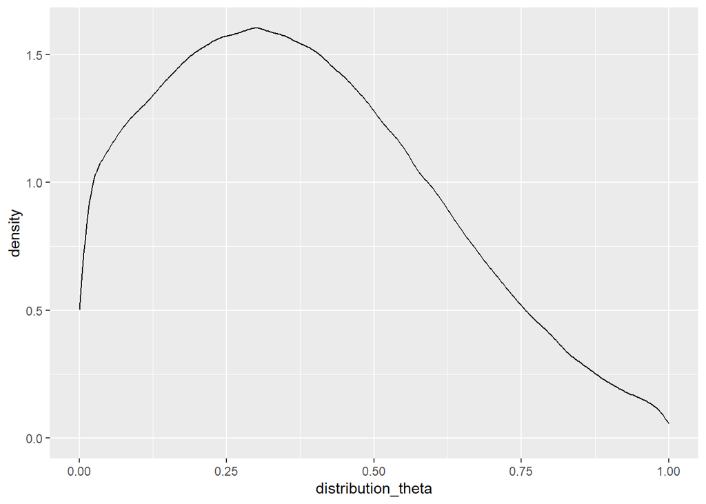

```r
distribution_theta = rnorm(n = 1000000, mean = 0.3, sd = 0.3)
distribution_theta = distribution_theta[-which(distribution_theta < 0 | distribution_theta > 1)]
distribution_theta = round(distribution_theta, 2)
library(ggplot2)
ggplot() + geom_density(aes(x = distribution_theta),
                       method = 'loess')
```

Around 10 percent of people are selfish, corresponding to a theta > 0.7 in this equation

```r
sum(distribution_theta > 0.7)/length(distribution_theta)
```

```
## [1] 0.09463088
```

We’ll sample phi values randomly. We’ll also use a default number of trials of 60.

```r
nTrials = 60
```

Sample the parameter space for the maximum number of observations: 1000

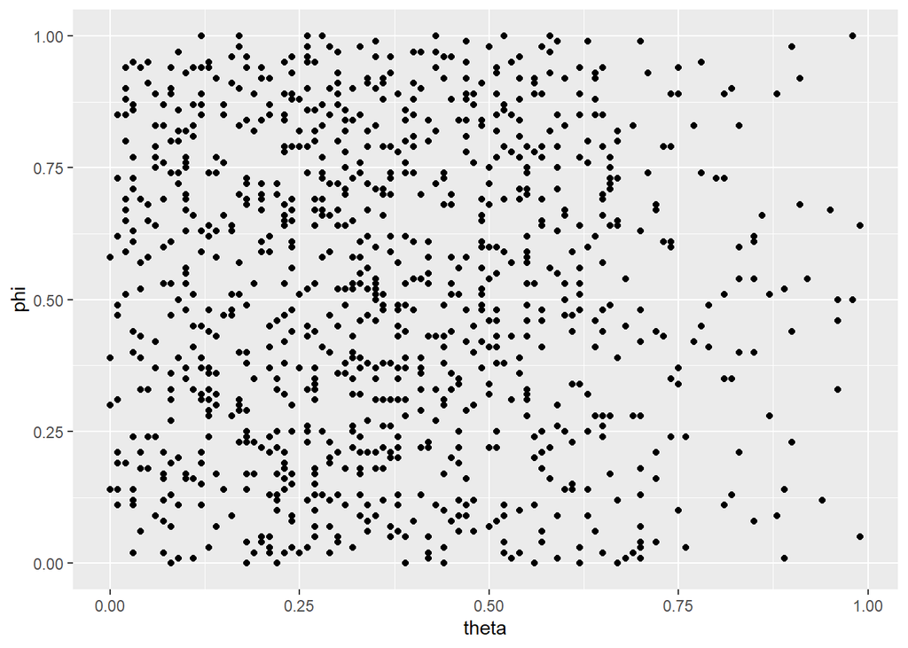

```r
n1000 = data.frame(theta = sample(distribution_theta, 1000),
                   phi = sample(freeParameters$phi, 1000))
ggplot(data = n1000) + geom_point(aes(x = theta, y = phi))
```

And save this information so that it can be used in the lower child scripts

```r
save.image(file = "C:/Users/DELL/Documents/socog/index.RData")
```